# AI&ML_ASSESSMENT 2

POONAM PRAFUL SHRISHRIMAL_s8075211

2023-09-06

```r
#Stop / hide warnings
options(warn = -1)
```

#### **Import the required libraries**

```r
# set options
options(stringsAsFactors = F)         # no automatic data transformation
options("scipen" = 100, "digits" = 4) # suppress math annotation
# load packages
library(knitr)
library(DT)
library(tm)
```

```r
library(topicmodels)
library(reshape2)
library(ggplot2)
library(wordcloud)
library(pals)
library(SnowballC)
library(lda)
library(ldatuning)
library(flextable)
```

#### **Import the data**

```r
# load data
df=read.csv("E:/VU SYDNEY/AI&ML/Speechdata.csv")
```

#### **Data Review**

*Reviewing the data is a critical step in any data analysis or machine learning project. It helps ensure the quality, integrity, and suitability of the data for the intended analysis or modeling task.It allows us to understand the data structure, type and also help us to identify errors and inconsistencies.*

```r
head(df)  # View the first few rows
```

|  | doc_id | speech_doc_id | speech_type | president | date | text |
| --- | --- | --- | --- | --- | --- | --- |
| 1 | 1 | 1 | State of the Union Address | George Washington | 1790-01-08 | Fellow-Citizens of the Senate and House of Representatives: |
| 2 | 2 | 1 | State of the Union Address | George Washington | 1790-01-08 | I embrace with great satisfaction the opportunity which now presents itself\nof congratulating you on the present favorable prospects of our public\naffairs. The recent accession of the important stat… |
| 3 | 3 | 1 | State of the Union Address | George Washington | 1790-01-08 | In resuming your consultations for the general good you can not but derive\nencouragement from the reflection that the measures of the last session\nhave been as satisfactory to your constituents as t… |
| 4 | 4 | 1 | State of the Union Address | George Washington | 1790-01-08 | Among the many interesting objects which will engage your attention that of\nproviding for the common defense will merit particular regard. To be\nprepared for war is one of the most effectual means o… |
| 5 | 5 | 1 | State of the Union Address | George Washington | 1790-01-08 | A free people ought not only to be armed, but disciplined; to which end a\nuniform and well-digested plan is requisite; and their safety and interest\nrequire that they should promote such manufactori… |
| 6 | 6 | 1 | State of the Union Address | George Washington | 1790-01-08 | The proper establishment of the troops which may be deemed indispensable\nwill be entitled to mature consideration. In the arrangements which may be\nmade respecting it it will be of importance to con… |

```r
tail(df)  # View the last few rows
```

|  | doc_id | speech_doc_id | speech_type | president | date | text |
| --- | --- | --- | --- | --- | --- | --- |
| 8828 | 8828 | 115 | State of the Union Address | Theodore Roosevelt | 1903-12-07 | The Indian agents should not be dependent for their appointment or\ntenure of office upon considerations of partisan politics; the practice\nof appointing, when possible, ex-army officers or bonded\ns… |
| 8829 | 8829 | 115 | State of the Union Address | Theodore Roosevelt | 1903-12-07 | In my last annual Message the attention of the Congress was called to\nthe necessity of enlarging the safety-appliance law, and it is\ngratifying to note that this law was amended in important respect… |
| 8830 | 8830 | 115 | State of the Union Address | Theodore Roosevelt | 1903-12-07 | No other class of our citizens deserves so well of the Nation as those\nto whom the Nation owes its very being, the veterans of the civil war.\nSpecial attention is asked to the excellent work of the … |
| 8831 | 8831 | 115 | State of the Union Address | Theodore Roosevelt | 1903-12-07 | During the year ended June 30 last 25,566 persons were appointed\nthrough competitive examinations under the civil-service rules. This\nwas 12,672 more than during the preceding year, and 40 per cent … |
| 8832 | 8832 | 115 | State of the Union Address | Theodore Roosevelt | 1903-12-07 | The Congress, as the result of a thorough investigation of the\ncharities and reformatory institutions in the District of Columbia, by\na joint select committee of the two Houses which made its report… |
| 8833 | 8833 | 115 | State of the Union Address | Theodore Roosevelt | 1903-12-07 | The effect of the laws providing a General Staff for the Army and for\nthe more effective use of the National Guard has been excellent. Great\nimprovement has been made in the efficiency of our Army i… |

*After reviewing the data it is clear that we need to clean it. There are lot of symbols and stopwords use which will not serve meaningful in our analysis and will give unexpected results so data cleaning and pre-processing is must here.*

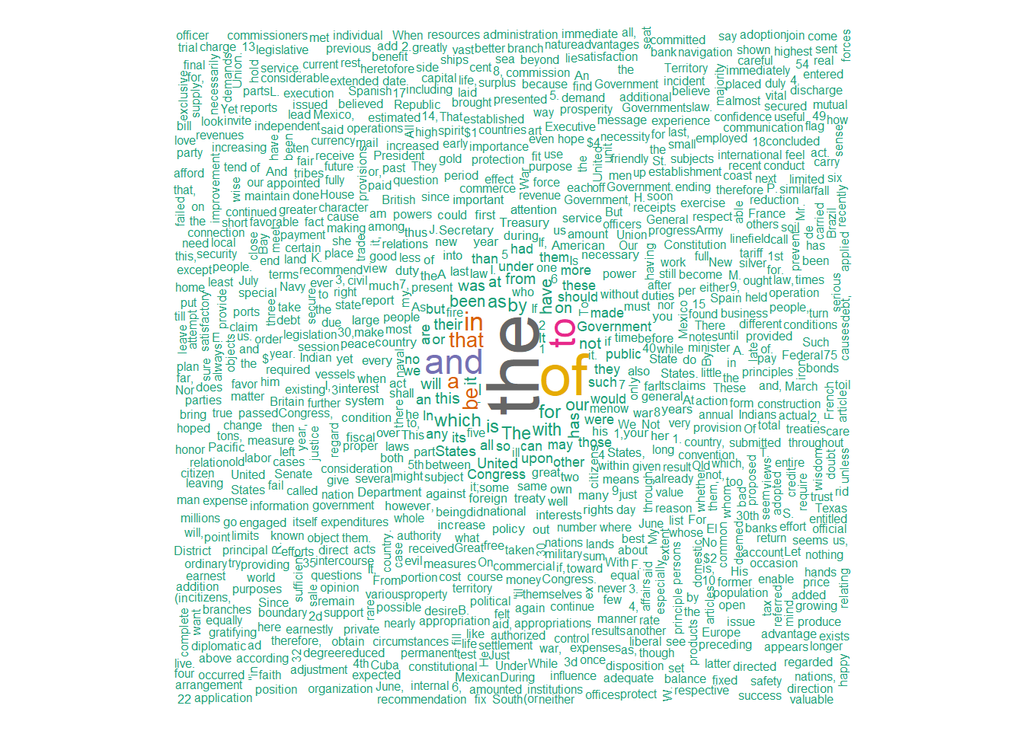

```r
#Let's create a word cloud

# Load the required library
library(wordcloud)

# Tokenize the "text" column into words
words <- unlist(strsplit(df$text, " "))

# Calculate word frequencies
word_freq <- table(words)

# Sort the word frequencies in descending order
sorted_word_freq <- sort(word_freq, decreasing = TRUE)

# Create a word cloud with all words
wordcloud(words = names(sorted_word_freq),
          freq = sorted_word_freq,
          scale = c(3, 0.5), random.order = FALSE,
          colors = brewer.pal(8, "Dark2"))
```

```r
#Lets create a frequency plot of words

# Load required libraries
library(wordcloud)
library(RColorBrewer)
library(ggplot2)

# Tokenize the "text" column into words
words <- unlist(strsplit(df$text, " "))

# Calculate word frequencies
word_freq <- table(words)

# Sort the word frequencies in descending order
sorted_word_freq <- sort(word_freq, decreasing = TRUE)

# Select the top 30 words
top_30_words <- head(sorted_word_freq, 30)

# Create a data frame with appropriate column names
plot_data <- data.frame(Words = names(top_30_words), Frequency = as.numeric(top_30_words))
```

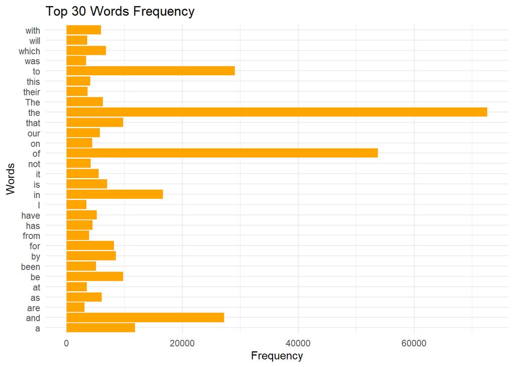

```r
# Create a frequency plot
ggplot(plot_data, aes(x = Words, y = Frequency)) +
  geom_bar(stat = "identity", fill = "orange") +
  labs(title = "Top 30 Words Frequency", x = "Words", y = "Frequency") +
  theme_minimal() +
  coord_flip()
```

*After reviewing the data it is clear that we need to clean it. There are lot of symbols and stopwords use which will not serve meaningful in our analysis and will give unexpected results so data cleaning and pre-processing is must here.*

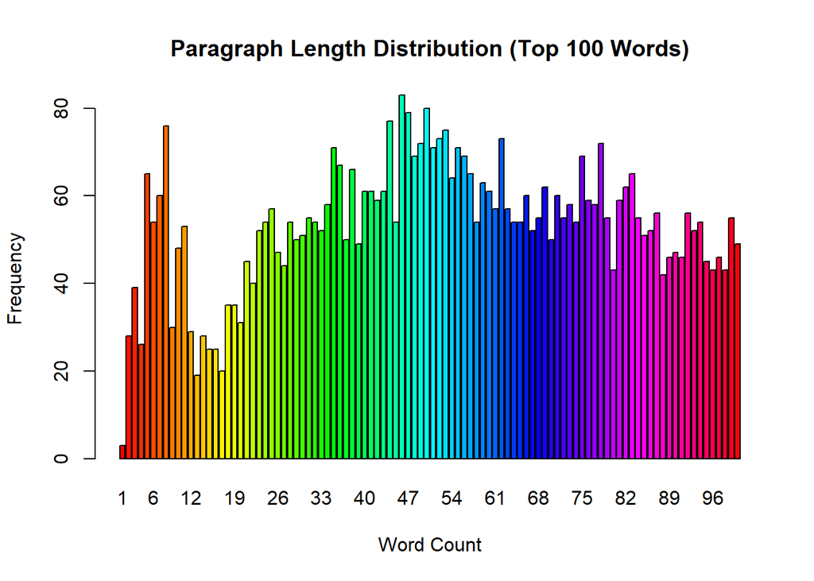

```r
# Calculate paragraph lengths
paragraph_lengths <- sapply(df$text, function(x) length(unlist(strsplit(x, " "))))

# Create a bar plot with colors and limit to 100 words
top_100_lengths <- paragraph_lengths[paragraph_lengths <= 100]  # Filter to 100 words or fewer

# Create a color palette (adjust the number of colors as needed)
colors <- rainbow(length(unique(top_100_lengths)))

# Create a bar plot with colors
barplot(table(top_100_lengths), main = "Paragraph Length Distribution (Top 100 Words)",
        xlab = "Word Count", ylab = "Frequency", col = colors)
```

#### **Data Cleaning and Pre-processing**

*Cleaning data is crucial because it ensures the accuracy, reliability, and effectiveness of your analysis and decision-making processes.*

```r
# Load the required libraries
library(tm)

# Create a corpus from the text data
corpus <- Corpus(DataframeSource(df))

# Preprocessing chain
processedCorpus <- tm_map(corpus, content_transformer(tolower))  # Convert to lowercase
processedCorpus <- tm_map(processedCorpus, removePunctuation)  # Remove punctuation
processedCorpus <- tm_map(processedCorpus, removeNumbers)  # Remove numbers

# Remove inbuilt English stopwords
processedCorpus <- tm_map(processedCorpus, removeWords, stopwords("en"))

# Stemming (if desired, you can skip this step if it doesn't improve results)
processedCorpus <- tm_map(processedCorpus, stemDocument, language = "en")

# Strip extra whitespace
processedCorpus <- tm_map(processedCorpus, stripWhitespace)
```

```r
# compute document term matrix with terms >= minimumFrequency
minimumFrequency <- 5
DTM <- DocumentTermMatrix(processedCorpus, control = list(bounds = list(global = c(minimumFrequency, Inf))))
```

```r
# due to vocabulary pruning, we have empty rows in our DTM
# LDA does not like this. So we remove those docs from the
# DTM and the metadata
sel_idx <- slam::row_sums(DTM) > 0
DTM <- DTM[sel_idx, ]
df<- df[sel_idx, ]
```

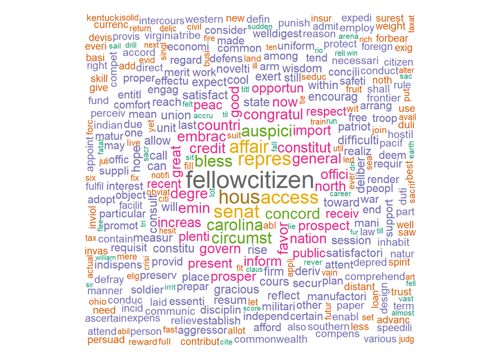

```r
#Lets create a word cloud

# Get the terms (words) from the DTM
terms <- Terms(DTM)

# Create a named vector of word frequencies
word_freq <- as.vector(slam::row_sums(DTM))

# Sort the word frequencies in descending order
sorted_word_freq <- sort(word_freq, decreasing = TRUE)

# Filter the word frequencies to include only non-zero values
non_zero_word_freq <- sorted_word_freq[sorted_word_freq > 0]

# Create a word cloud with all words
wordcloud(words = terms,
          freq = non_zero_word_freq,
          scale = c(2, 0.5), random.order = FALSE,
          colors = brewer.pal(8, "Dark2"))
```

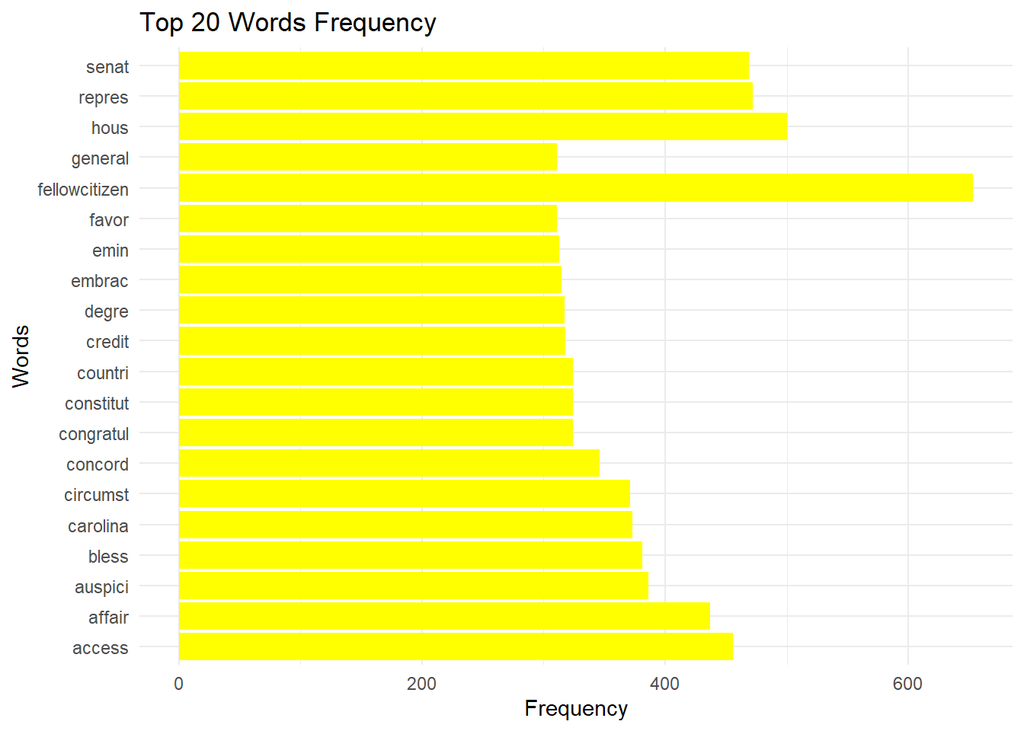

```r
#Lets create a frequency plot of words

# Get the terms (words) from the DTM
terms <- Terms(DTM)

# Create a named vector of word frequencies
word_freq <- as.vector(slam::row_sums(DTM))

# Sort the word frequencies in descending order
sorted_word_freq <- sort(word_freq, decreasing = TRUE)

# Filter the word frequencies to include only non-zero values
non_zero_word_freq <- sorted_word_freq[sorted_word_freq > 0]

# Select the top N words (e.g., top 20 words)
top_N <- 20
top_terms <- terms[1:top_N]
top_freq <- non_zero_word_freq[1:top_N]

# Create a data frame for the bar plot
plot_data <- data.frame(Words = top_terms, Frequency = top_freq)

# Create a bar plot with flipped coordinates and minimal theme
library(ggplot2)
ggplot(plot_data, aes(x = Frequency, y = Words)) +
  geom_bar(stat = "identity", fill = "yellow") +
  labs(title = "Top 20 Words Frequency", x = "Frequency", y = "Words") +
  theme_minimal() +
  theme(legend.position = "none") # Remove the legend for fill
```

*After cleaning the data this world cloud now make sense and we can tell about the content of the speech.*

#### **Model Building**

##### **1. Finding Value of k:**

*For models with parameters like Latent Dirichlet Allocation (LDA), selecting the number of topics i.e., K, is a crucial step. The choice of the optimal K depends on various factors. If K is set too low, the collection is segmented into only a few broad semantic contexts. Conversely, if K is excessively high, the collection is split into numerous topics, some of which might overlap, while others become challenging to interpret.*

##### **a.Perplexity**

*We will use a perplexity approach first and try to get the number of topics through minimum perplexity.*

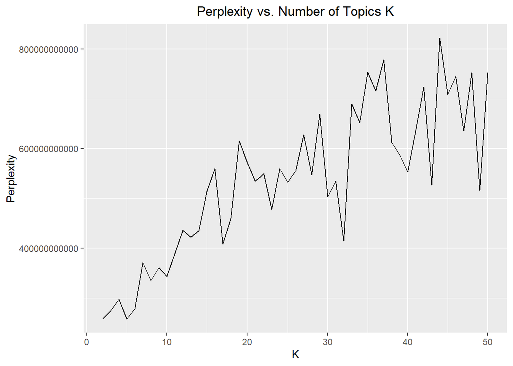

```r
set.seed(87460945)

# Calculate folds
idxs <- sample(seq_len(9))
folds <- split(idxs, rep(1:3, each = 3, length.out = 9))

# Define number of topics
topics <- seq(2, 50, 1)

# Create data frame for storing results
results <- data.frame()

# Perform cross-validation
for (k in topics) {
  scores <- c()
  for (i in 1:3) {
    test_idx <- folds[[i]]
    train_idx <- setdiff(unlist(folds, use.names = FALSE), test_idx)

    test <- DTM[test_idx, ]
    train <- DTM[train_idx, ]

    LDA.out <- LDA(train, k, method = "Gibbs")

    # Calculate perplexity for the test data
    log_likelihood <- logLik(LDA.out, newdata = test)
    n_tokens_test <- sum(test)
    perplexity <- exp(-sum(log_likelihood) / n_tokens_test)

    scores <- c(scores, perplexity)
  }
  temp <- data.frame("K" = k, "Perplexity" = mean(scores))
  results <- rbind(results, temp)
}

# Plot Perplexity vs. K
library(ggplot2)
ggplot(results, aes(x = K, y = Perplexity)) +
  geom_line() +
  ggtitle("Perplexity vs. Number of Topics K") +
  theme(plot.title = element_text(hjust = 0.5))
```

```r
# Find the row with the minimum perplexity
min_perplexity_row <- results[which.min(results$Perplexity), ]

# Extract the minimum perplexity value and corresponding K value
min_perplexity <- min_perplexity_row$Perplexity
corresponding_K <- min_perplexity_row$K

# Print the results
cat("Minimum Perplexity:", min_perplexity, "\n")
```

```
## Minimum Perplexity: 258255023132
```

```r
cat("Corresponding K (Number of Topics):", corresponding_K, "\n")
```

```
## Corresponding K (Number of Topics): 5
```

*From the above graph of perplexity though the minimum perplexity is at 5 number of topics but still we can see that there are multiple elbow points so we need to consider other approaches or a combination of methods to make an informed decision*

##### **b. FindTopicNumber**

*We will use a FindTopicNumber approach to determining the number of topics which explores a range of values rather than fixating on a specific number.We will use only two metrics (CaoJuan2009 and Deveaud2014)*

```r
# create models with different number of topics
result <- ldatuning::FindTopicsNumber(
  DTM,
  topics = seq(from = 2, to = 20, by = 1),
  metrics = c("CaoJuan2009",  "Deveaud2014"),
  method = "Gibbs",
  control = list(seed = 77),
  verbose = TRUE
)
```

```
## fit models... done.
## calculate metrics:
##   CaoJuan2009... done.
##   Deveaud2014... done.
```

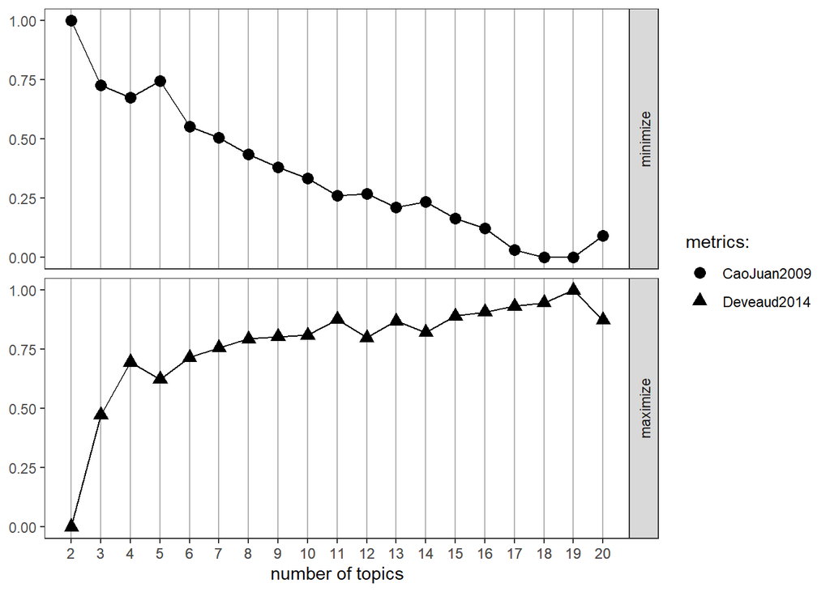

```r
#Plot the results
FindTopicsNumber_plot(result)
```

#### **Model Fitting**

```r
# number of topics
K <- 20

# set random number generator seed
set.seed(9161)

# compute the LDA model, inference via 1000 iterations of Gibbs sampling
topicModel <- LDA(DTM, K, method="Gibbs", control=list(iter = 500, verbose = 25))
```

```
## K = 20; V = 4479; M = 8811
## Sampling 500 iterations!
## Iteration 25 ...
## Iteration 50 ...
## Iteration 75 ...
## Iteration 100 ...
## Iteration 125 ...
## Iteration 150 ...
## Iteration 175 ...
## Iteration 200 ...
## Iteration 225 ...
## Iteration 250 ...
## Iteration 275 ...
## Iteration 300 ...
## Iteration 325 ...
## Iteration 350 ...
## Iteration 375 ...
## Iteration 400 ...
## Iteration 425 ...
## Iteration 450 ...
## Iteration 475 ...
## Iteration 500 ...
## Gibbs sampling completed!
```

```r
# have a look a some of the results (posterior distributions)
tmResult <- posterior(topicModel)
# format of the resulting object
attributes(tmResult)
```

```
## $names
## [1] "terms"  "topics"
```

```r
nTerms(DTM)              # lengthOfVocab
```

```
## [1] 4479
```

```r
# topics are probability distributions over the entire vocabulary
beta <- tmResult$terms   # get beta from results
dim(beta)                # K distributions over nTerms(DTM) terms
```

```
## [1]   20 4479
```

```r
rowSums(beta)            # rows in beta sum to 1
```

```
##  1  2  3  4  5  6  7  8  9 10 11 12 13 14 15 16 17 18 19 20
##  1  1  1  1  1  1  1  1  1  1  1  1  1  1  1  1  1  1  1  1
```

```r
nDocs(DTM)               # size of collection
```

```
## [1] 8811
```

```r
# for every document we have a probability distribution of its contained topics
theta <- tmResult$topics
dim(theta)               # nDocs(DTM) distributions over K topics
```

```
## [1] 8811   20
```

```r
rowSums(theta)[1:10]     # rows in theta sum to 1
```

```
##  1  2  3  4  5  6  7  8  9 10
##  1  1  1  1  1  1  1  1  1  1
```

*Let us now look more closely at the distribution of topics within individual documents. To this end, we visualize the distribution in 3 sample documents.Let us first take a look at the contents of three sample documents:*

```r
exampleIds <- c(2, 100, 200)
lapply(corpus[exampleIds], as.character)
```

```
## $`2`
## [1] "I embrace with great satisfaction the opportunity which now presents itself\nof congratulating you on the present favorable prospects of our public\naffairs. The recent accession of the important state of North Carolina to\nthe Constitution of the United States (of which official information…
##
## $`100`
## [1] "Provision is likewise requisite for the reimbursement of the loan which has\nbeen made of the Bank of the United States, pursuant to the eleventh\nsection of the act by which it is incorporated. In fulfilling the public\nstipulations in this particular it is expected a valuable saving will b…
##
## $`200`
## [1] "After many delays and disappointments arising out of the European war, the\nfinal arrangements for fulfilling the engagements made to the Dey and\nRegency of Algiers will in all present appearance be crowned with success,\nbut under great, though inevitable, disadvantages in the pecuniary\nt…
```

```r
exampleIds <- c(2, 100, 200)
print(paste0(exampleIds[1], ": ", substr(content(corpus[[exampleIds[1]]]), 0, 400), '...'))
```

```
## [1] "2: I embrace with great satisfaction the opportunity which now presents itself\nof congratulating you on the present favorable prospects of our public\naffairs. The recent accession of the important state of North Carolina to\nthe Constitution of the United States (of which official informat…
```

```r
print(paste0(exampleIds[2], ": ", substr(content(corpus[[exampleIds[2]]]), 0, 400), '...'))
```

```
## [1] "100: Provision is likewise requisite for the reimbursement of the loan which has\nbeen made of the Bank of the United States, pursuant to the eleventh\nsection of the act by which it is incorporated. In fulfilling the public\nstipulations in this particular it is expected a valuable saving w…
```

```r
print(paste0(exampleIds[3], ": ", substr(content(corpus[[exampleIds[3]]]), 0, 400), '...'))
```

```
## [1] "200: After many delays and disappointments arising out of the European war, the\nfinal arrangements for fulfilling the engagements made to the Dey and\nRegency of Algiers will in all present appearance be crowned with success,\nbut under great, though inevitable, disadvantages in the pecunia…
```

#### **MODEL EVALUATION**

*Lets visualize the topic distributions within the documents*

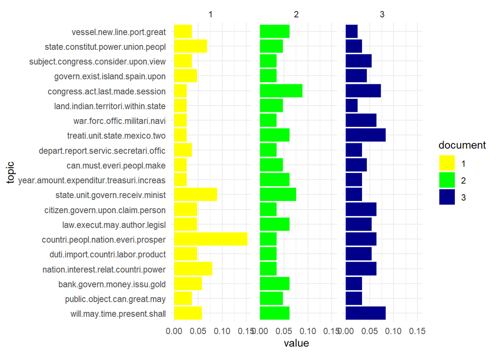

```r
N <- length(exampleIds)
# get topic proportions form example documents
topicProportionExamples <- theta[exampleIds,]
colnames(topicProportionExamples) <- topicNames
vizDataFrame <- melt(cbind(data.frame(topicProportionExamples), document = factor(1:N)), variable.name = "topic", id.vars = "document")
ggplot(data = vizDataFrame, aes(topic, value, fill = document), ylab = "proportion") +
  geom_bar(stat = "identity") +
  theme(axis.text.x = element_text(angle = 90, hjust = 1)) +
  coord_flip() +
  facet_wrap(~ document, ncol = N) +
  scale_fill_manual(values = c("yellow", "green", "darkblue"))+theme_minimal()
```

*The diagram above illustrates the distribution of topics within a document based on the model. In the current model, all three documents exhibit some degree of each topic, but a few topics dominate each document*

*The allocation of topics within a document can be adjusted using the Alpha parameter of the model. Higher Alpha priors for topics lead to a more uniform distribution of topics within a document, while lower Alpha priors ensure that the inference process concentrates the probability on a select few topics for each document*

*Now, let’s modify the Alpha prior to a lower value to observe its impact on the topic distributions in the model.*

```r
# see alpha from previous model
attr(topicModel, "alpha")
```

```
## [1] 2.5
```

```r
topicModel2 <- LDA(DTM, K, method="Gibbs", control=list(iter = 500, verbose = 25, alpha = 0.2))
```

```
## K = 20; V = 4479; M = 8811
## Sampling 500 iterations!
## Iteration 25 ...
## Iteration 50 ...
## Iteration 75 ...
## Iteration 100 ...
## Iteration 125 ...
## Iteration 150 ...
## Iteration 175 ...
## Iteration 200 ...
## Iteration 225 ...
## Iteration 250 ...
## Iteration 275 ...
## Iteration 300 ...
## Iteration 325 ...
## Iteration 350 ...
## Iteration 375 ...
## Iteration 400 ...
## Iteration 425 ...
## Iteration 450 ...
## Iteration 475 ...
## Iteration 500 ...
## Gibbs sampling completed!
```

```r
tmResult <- posterior(topicModel2)
theta <- tmResult$topics
beta <- tmResult$terms
topicNames <- apply(terms(topicModel2, 5), 2, paste, collapse = " ")  # reset topicnames
```

*Now visualize the topic distributions in the three documents again and see the difference.*

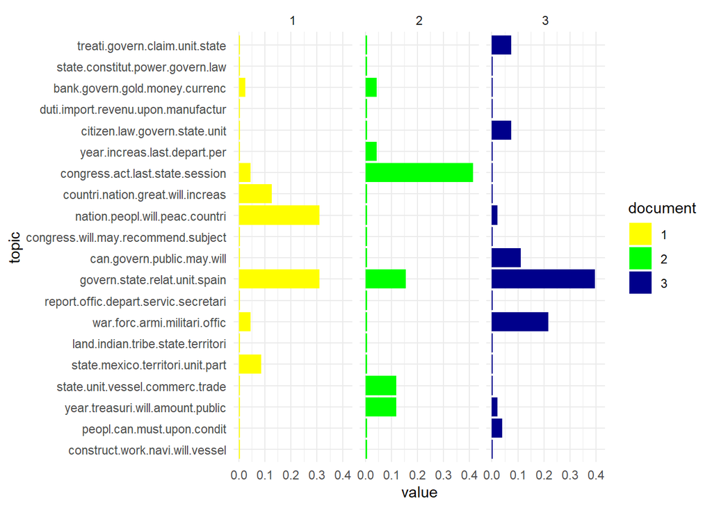

```r
# get topic proportions form example documents
topicProportionExamples <- theta[exampleIds,]
colnames(topicProportionExamples) <- topicNames
vizDataFrame <- melt(cbind(data.frame(topicProportionExamples), document = factor(1:N)), variable.name = "topic", id.vars = "document")
ggplot(data = vizDataFrame, aes(topic, value, fill = document), ylab = "proportion") +
  geom_bar(stat = "identity") +
  theme(axis.text.x = element_text(angle = 90, hjust = 1)) +
  coord_flip() +
  facet_wrap(~ document, ncol = N) +
  scale_fill_manual(values = c("yellow", "green", "darkblue"))+theme_minimal()
```

*We can see that the inference process distributes the probability mass on a few topics for each document..*

#### **Topic Ranking**

*Initially, we aim to establish a more significant arrangement of the most important terms for each topic by assigning them a particular score. This concept of reordering terms shares similarities with the TF-IDF (Term Frequency-Inverse Document Frequency) approach. Essentially, if a term frequently appears at higher levels relative to its probability, it becomes less valuable in terms of describing the topic. Consequently, this scoring method gives preference to terms that effectively represent a topic*

```r
# re-rank top topic terms for topic names
topicNames <- apply(lda::top.topic.words(beta, 5, by.score = T), 2, paste, collapse = " ")
```

*What are the defining topics within a collection? There are different approaches to find out which can be used to bring the topics into a certain order.*

###### **Approach 1**

*We sort topics according to their probability within the entire collection*

```r
# What are the most probable topics in the entire collection?
topicProportions <- colSums(theta) / nDocs(DTM)  # mean probabilities over all paragraphs
names(topicProportions) <- topicNames     # assign the topic names we created before
sort(topicProportions, decreasing = TRUE) # show summed proportions in decreased order
```

```
##               public can may object power
##                                   0.06427
##           relat spain govern state minist
##                                   0.06358
##    congress recommend attent will subject
##                                   0.05979
##         nation peac peopl prosper countri
##                                   0.05968
##      report depart offic servic secretari
##                                   0.05924
##           treati claim convent senat unit
##                                   0.05602
##           state constitut power law union
##                                   0.05321
##      year treasuri amount expenditur debt
##                                   0.05197
##           congress act last session state
##                                   0.05124
##             citizen law claim case person
##                                   0.04882
##                  peopl can must labor men
##                                   0.04805
## countri nation increas product agricultur
##                                   0.04803
##              war armi forc militari offic
##                                   0.04695
##              state unit vessel port trade
##                                   0.04636
##           construct navi vessel work ship
##                                   0.04414
##                year increas per last cent
##                                   0.04195
##            bank gold currenc silver money
##                                   0.04122
##     duti revenu tariff manufactur product
##                                   0.04088
##           land indian tribe territori acr
##                                   0.03839
##          mexico state territori texa unit
##                                   0.03622
```

```r
# What are the most probable topics in the entire collection?
topicProportions <- colSums(theta) / nDocs(DTM)  # mean probabilities over all paragraphs
names(topicProportions) <- topicNames     # assign the topic names we created before
sort(topicProportions, decreasing = TRUE) # show summed proportions in decreased order
```

```
##               public can may object power
##                                   0.06427
##           relat spain govern state minist
##                                   0.06358
##    congress recommend attent will subject
##                                   0.05979
##         nation peac peopl prosper countri
##                                   0.05968
##      report depart offic servic secretari
##                                   0.05924
##           treati claim convent senat unit
##                                   0.05602
##           state constitut power law union
##                                   0.05321
##      year treasuri amount expenditur debt
##                                   0.05197
##           congress act last session state
##                                   0.05124
##             citizen law claim case person
##                                   0.04882
##                  peopl can must labor men
##                                   0.04805
## countri nation increas product agricultur
##                                   0.04803
##              war armi forc militari offic
##                                   0.04695
##              state unit vessel port trade
##                                   0.04636
##           construct navi vessel work ship
##                                   0.04414
##                year increas per last cent
##                                   0.04195
##            bank gold currenc silver money
##                                   0.04122
##     duti revenu tariff manufactur product
##                                   0.04088
##           land indian tribe territori acr
##                                   0.03839
##          mexico state territori texa unit
##                                   0.03622
```

```r
soP <- sort(topicProportions, decreasing = TRUE)
paste(round(soP, 5), ":", names(soP))
```

```
##  [1] "0.06427 : public can may object power"
##  [2] "0.06358 : relat spain govern state minist"
##  [3] "0.05979 : congress recommend attent will subject"
##  [4] "0.05968 : nation peac peopl prosper countri"
##  [5] "0.05924 : report depart offic servic secretari"
##  [6] "0.05602 : treati claim convent senat unit"
##  [7] "0.05321 : state constitut power law union"
##  [8] "0.05197 : year treasuri amount expenditur debt"
##  [9] "0.05124 : congress act last session state"
## [10] "0.04882 : citizen law claim case person"
## [11] "0.04805 : peopl can must labor men"
## [12] "0.04803 : countri nation increas product agricultur"
## [13] "0.04695 : war armi forc militari offic"
## [14] "0.04636 : state unit vessel port trade"
## [15] "0.04414 : construct navi vessel work ship"
## [16] "0.04195 : year increas per last cent"
## [17] "0.04122 : bank gold currenc silver money"
## [18] "0.04088 : duti revenu tariff manufactur product"
## [19] "0.03839 : land indian tribe territori acr"
## [20] "0.03622 : mexico state territori texa unit"
```

###### **Approach 2**

*We count how often a topic appears as a primary topic within a paragraph This method is also called Rank-1*

```r
countsOfPrimaryTopics <- rep(0, K)
names(countsOfPrimaryTopics) <- topicNames
for (i in 1:nDocs(DTM)) {
  topicsPerDoc <- theta[i, ] # select topic distribution for document i
  # get first element position from ordered list
  primaryTopic <- order(topicsPerDoc, decreasing = TRUE)[1]
  countsOfPrimaryTopics[primaryTopic] <- countsOfPrimaryTopics[primaryTopic] + 1
}
sort(countsOfPrimaryTopics, decreasing = TRUE)
```

```
##           relat spain govern state minist
##                                       685
##           treati claim convent senat unit
##                                       594
##      report depart offic servic secretari
##                                       588
##               public can may object power
##                                       557
##         nation peac peopl prosper countri
##                                       550
##      year treasuri amount expenditur debt
##                                       484
##    congress recommend attent will subject
##                                       468
##           construct navi vessel work ship
##                                       440
##           state constitut power law union
##                                       433
##              state unit vessel port trade
##                                       429
##              war armi forc militari offic
##                                       418
##             citizen law claim case person
##                                       401
##            bank gold currenc silver money
##                                       395
##           land indian tribe territori acr
##                                       375
##                  peopl can must labor men
##                                       364
##           congress act last session state
##                                       360
##                year increas per last cent
##                                       355
## countri nation increas product agricultur
##                                       353
##     duti revenu tariff manufactur product
##                                       297
##          mexico state territori texa unit
##                                       265
```

```r
so <- sort(countsOfPrimaryTopics, decreasing = TRUE)
paste(so, ":", names(so))
```

```
##  [1] "685 : relat spain govern state minist"
##  [2] "594 : treati claim convent senat unit"
##  [3] "588 : report depart offic servic secretari"
##  [4] "557 : public can may object power"
##  [5] "550 : nation peac peopl prosper countri"
##  [6] "484 : year treasuri amount expenditur debt"
##  [7] "468 : congress recommend attent will subject"
##  [8] "440 : construct navi vessel work ship"
##  [9] "433 : state constitut power law union"
## [10] "429 : state unit vessel port trade"
## [11] "418 : war armi forc militari offic"
## [12] "401 : citizen law claim case person"
## [13] "395 : bank gold currenc silver money"
## [14] "375 : land indian tribe territori acr"
## [15] "364 : peopl can must labor men"
## [16] "360 : congress act last session state"
## [17] "355 : year increas per last cent"
## [18] "353 : countri nation increas product agricultur"
## [19] "297 : duti revenu tariff manufactur product"
## [20] "265 : mexico state territori texa unit"
```

*We observe that when we arrange topics using the Rank-1 method, topics characterized by fairly distinct thematic cohesiveness are positioned towards the top of the list.*

*This organization of topics can be applied to subsequent analysis procedures, including interpreting the semantic content of topics within the collection, examining time series data related to the most significant topics, or filtering the original collection based on particular sub-topics.*

#### **Filtering the Documents**

*The availability of topic probabilities for each document, or in our case, each paragraph, within a topic model enables us to employ it for thematic filtration of a collection. As part of the filtering process, we choose to retain only those documents that surpass a specific threshold in terms of their probability value for particular topics. For instance, we may opt to retain every document that contains more than 20 percent of topic X.*

*In the subsequent steps, we will filter documents based on their topic content and illustrate how this impacts the overall number of documents over time.*

```r
topicToFilter <- 6  # you can set this manually ...
# ... or have it selected by a term in the topic name (e.g. 'children')
topicToFilter <- grep('children', topicNames)[1]
topicThreshold <- 0.2
selectedDocumentIndexes <- which(theta[, topicToFilter] >= topicThreshold)
filteredCorpus <- corpus[selectedDocumentIndexes]
# show length of filtered corpus
filteredCorpus
```

```
## <<SimpleCorpus>>
## Metadata:  corpus specific: 1, document level (indexed): 4
## Content:  documents: 0
```

*Our filtered corpus contains 0 documents related to the topic NA to at least 20 %*

#### **Topic Proportions over Time**

*Finally, we take a broader look at the evolution of topics within the dataset across different time periods. To achieve this, we calculate the average topic proportions for each decade, considering all State of the Union (SOTU) speeches. These consolidated topic proportions can then be represented visually, for example, in the form of a bar plot.*

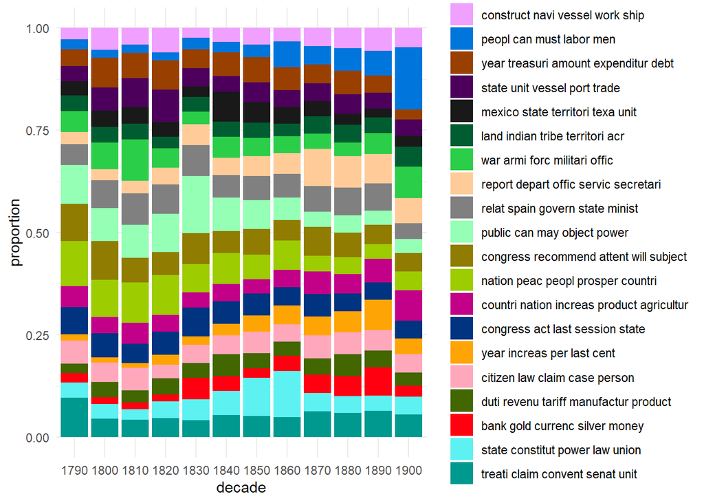

```r
# append decade information for aggregation
df$decade <- paste0(substr(df$date, 0, 3), "0")
# get mean topic proportions per decade
topic_proportion_per_decade <- aggregate(theta, by = list(decade = df$decade), mean)
# set topic names to aggregated columns
colnames(topic_proportion_per_decade)[2:(K+1)] <- topicNames
# reshape data frame
vizDataFrame <- melt(topic_proportion_per_decade, id.vars = "decade")
# plot topic proportions per decade as bar plot
ggplot(vizDataFrame, aes(x=decade, y=value, fill=variable)) +
  geom_bar(stat = "identity") + ylab("proportion") +
  scale_fill_manual(values = paste0(alphabet(20), "FF"), name = "decade") +
  theme(axis.text.x = element_text(angle = 90, hjust = 1))+theme_minimal()
```

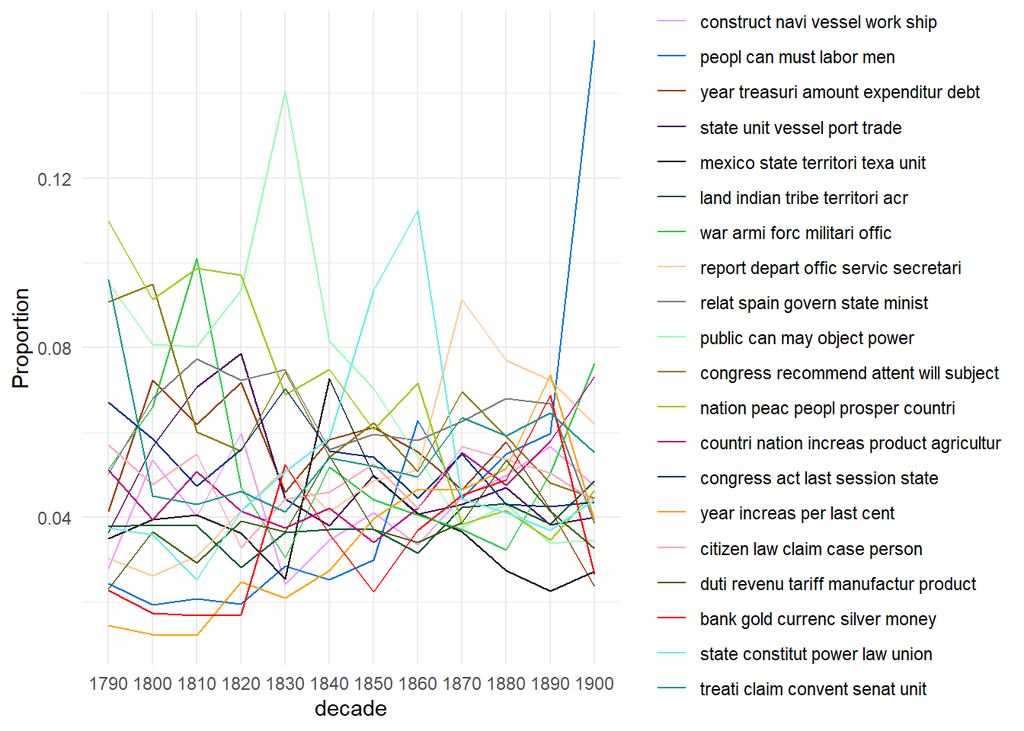

```r
#Lets plot a line chart

# Load required libraries
library(ggplot2)

# Your data preparation code (append decade information and aggregate) remains the same

# Reshape data frame for a line plot
vizDataFrame <- melt(topic_proportion_per_decade, id.vars = "decade")

# Create a line plot for topic proportions per decade
ggplot(vizDataFrame, aes(x = decade, y = value, color = variable, group = variable)) +
  geom_line() +
  ylab("Proportion") +
  scale_color_manual(values = paste0(alphabet(20), "FF"), name = "Topic") +
  theme(axis.text.x = element_text(angle = 90, hjust = 1))+theme_minimal()
```